# MidtermReport

Sampath Dontharaju(Mid: M08879603)

November 28, 2015

### Data cleaning and data exploration:

### Goal:

#### goal of this step is to clean the given data and to transform the data to be suitable for data analysis

```
##    aircraft      duration         no_pasg       speed_ground
##  airbus:400   Min.   : 14.76   Min.   :29.00   Min.   : 27.74
##  boeing:400   1st Qu.:119.49   1st Qu.:55.00   1st Qu.: 65.87
##               Median :153.95   Median :60.00   Median : 79.64
##               Mean   :154.01   Mean   :60.13   Mean   : 79.54
##               3rd Qu.:188.91   3rd Qu.:65.00   3rd Qu.: 92.33
##               Max.   :305.62   Max.   :87.00   Max.   :141.22
##
##    speed_air          height           pitch          distance
##  Min.   : 90.00   Min.   :-3.546   Min.   :2.284   Min.   :  34.08
##  1st Qu.: 96.16   1st Qu.:23.338   1st Qu.:3.658   1st Qu.: 900.95
##  Median :100.99   Median :30.147   Median :4.020   Median :1267.44
##  Mean   :103.83   Mean   :30.122   Mean   :4.018   Mean   :1544.52
##  3rd Qu.:109.48   3rd Qu.:36.981   3rd Qu.:4.388   3rd Qu.:1960.44
##  Max.   :141.72   Max.   :59.946   Max.   :5.927   Max.   :6533.05
##  NA's   :600
```

### observation:

#### we can observe from the data that there are 800 observations and 8 variables

#### from the summary we can infer that there are **600** NA values in the speed_air.

### decision:

#### we cannot neglect the NA values and replace them with zeros. To fill the values with meaningfl random variables used the amelia() function in Amelia package which replaces the NA values with random values using bayesian classification

[output not shown]

### 2.Data Visualization

#### **goal**:Goal is to show the plots between all the variables and analyse the relationships between them

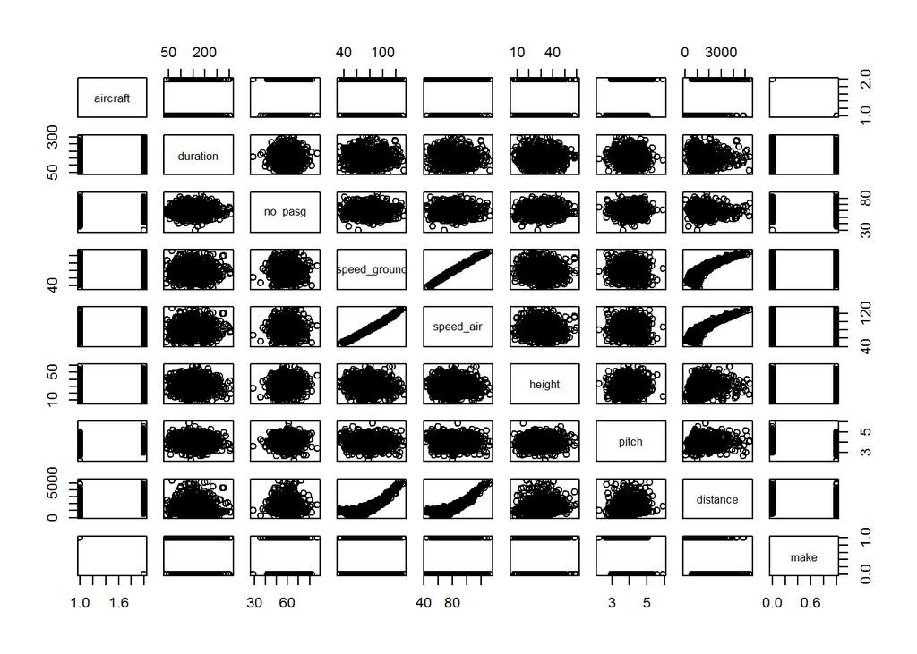

```
##                 duration      no_pasg speed_ground    speed_air
## duration      1.00000000 -0.036389581 -0.048970252 -0.037432882
## no_pasg      -0.03638958  1.000000000 -0.001489012 -0.008984225
## speed_ground -0.04897025 -0.001489012  1.000000000  0.995483035
## speed_air    -0.03743288 -0.008984225  0.995483035  1.000000000
## height        0.01111923  0.037308828 -0.051671805 -0.039975462
## pitch        -0.04675348 -0.014447586 -0.051670337 -0.042529606
## distance     -0.05138252 -0.016853121  0.867711454  0.893915962
## make          0.04442907  0.027481474  0.047671438  0.018888186
##                   height       pitch    distance        make
## duration      0.01111923 -0.04675348 -0.05138252  0.04442907
## no_pasg       0.03730883 -0.01444759 -0.01685312  0.02748147
## speed_ground -0.05167181 -0.05167034  0.86771145  0.04767144
## speed_air    -0.03997546 -0.04252961  0.89391596  0.01888819
## height        1.00000000  0.03473959  0.10372080  0.01504748
## pitch         0.03473959  1.00000000  0.06868102 -0.36201268
## distance      0.10372080  0.06868102  1.00000000 -0.22998335
## make          0.01504748 -0.36201268 -0.22998335  1.00000000
```

#### By looking at the correlation matrix we can say that **distance** is strongly coreleated with **speed_air** and **speed_ground**.

#### we can also see strong correlation between indepedent variables speed_air and speed_ground and therefore we might say that there exists a multicolinearity if we include both speed_air and speed_ground in our multiple regression model.

### 3.Model checking

### Goal:

#### Goal of model checking is to check the exact model which fits the data.Build models using all covariates and check the summary statistics and then make decisions whether to accept or create the model.

#### Observation: we first create a multi regression model with 7 indepedent variables and based on the summary and anova statistics of the model we remove that indpendent variables one at a time the independent variables which fail the p-test and f-statistics.

#### building the multiple regression model with distance as dependent. variable and all other variables as independent.

```
##
## Call:
## lm(formula = distance ~ (duration + no_pasg + speed_air + speed_ground +
##     height + pitch + make), data = landing_DAMdata)
##
## Residuals:
##     Min      1Q  Median      3Q     Max
## -798.70 -186.12  -29.56  133.05 1151.23
##
## Coefficients:
##                Estimate Std. Error t value Pr(>|t|)
## (Intercept)  -3649.3505   157.9339 -23.107  < 2e-16 ***
## duration        -0.5521     0.2116  -2.609  0.00925 **
## no_pasg          0.4650     1.3479   0.345  0.73024
## speed_air      140.1491     6.7907  20.638  < 2e-16 ***
## speed_ground   -81.6910     6.0446 -13.515  < 2e-16 ***
## height          11.3352     1.0498  10.798  < 2e-16 ***
## pitch           27.3722    20.7860   1.317  0.18828
## make          -348.3566    22.7315 -15.325  < 2e-16 ***
## ---
## Signif. codes:  0 '***' 0.001 '**' 0.01 '*' 0.05 '.' 0.1 ' ' 1
##
## Residual standard error: 282 on 773 degrees of freedom
## Multiple R-squared:  0.9037, Adjusted R-squared:  0.9028
## F-statistic:  1036 on 7 and 773 DF,  p-value: < 2.2e-16
```

```
## Analysis of Variance Table
##
## Response: distance
##               Df    Sum Sq   Mean Sq   F value    Pr(>F)
## duration       1   1685114   1685114   21.1878 4.866e-06 ***
## no_pasg        1    224037    224037    2.8169   0.09368 .
## speed_air      1 508379045 508379045 6392.1150 < 2.2e-16 ***
## speed_ground   1  35991044  35991044  452.5342 < 2.2e-16 ***
## height         1   7817022   7817022   98.2875 < 2.2e-16 ***
## pitch          1   4008453   4008453   50.4004 2.843e-12 ***
## make           1  18678145  18678145  234.8501 < 2.2e-16 ***
## Residuals    773  61478399     79532
## ---
## Signif. codes:  0 '***' 0.001 '**' 0.01 '*' 0.05 '.' 0.1 ' ' 1
```

### 4. Repeated exploration until best fit model is achieved

#### Goal: Goal of this step is to repeatedly build the models and check the summary statisctics and f-statistics values and remove one independent variable at a time until we get the best fit model.

#### observation: creating model(MultiregModel_6) with 6 independent variables(duration,no_pasg,speed_air,speed_ground,height+make) and by removing independent variable **pitch**.

```
##
## Call:
## lm(formula = distance ~ (duration + no_pasg + speed_air + speed_ground +
##     height + make), data = landing_DAMdata)
##
## Residuals:
##     Min      1Q  Median      3Q     Max
## -786.48 -186.23  -33.63  138.40 1158.12
##
## Coefficients:
##                Estimate Std. Error t value Pr(>|t|)
## (Intercept)  -3529.8037   129.2965 -27.300  < 2e-16 ***
## duration        -0.5613     0.2116  -2.652  0.00816 **
## no_pasg          0.4487     1.3485   0.333  0.73942
## speed_air      139.9881     6.7928  20.608  < 2e-16 ***
## speed_ground   -81.5741     6.0468 -13.490  < 2e-16 ***
## height          11.3959     1.0492  10.861  < 2e-16 ***
## make          -358.7831    21.3181 -16.830  < 2e-16 ***
## ---
## Signif. codes:  0 '***' 0.001 '**' 0.01 '*' 0.05 '.' 0.1 ' ' 1
##
## Residual standard error: 282.1 on 774 degrees of freedom
## Multiple R-squared:  0.9035, Adjusted R-squared:  0.9027
## F-statistic:  1207 on 6 and 774 DF,  p-value: < 2.2e-16
```

```
## Analysis of Variance Table
##
## Response: distance
##               Df    Sum Sq   Mean Sq   F value    Pr(>F)
## duration       1   1685114   1685114   21.1677 4.915e-06 ***
## no_pasg        1    224037    224037    2.8143   0.09383 .
## speed_air      1 508379045 508379045 6386.0581 < 2.2e-16 ***
## speed_ground   1  35991044  35991044  452.1054 < 2.2e-16 ***
## height         1   7817022   7817022   98.1944 < 2.2e-16 ***
## make           1  22548681  22548681  283.2477 < 2.2e-16 ***
## Residuals    774  61616317     79608
## ---
## Signif. codes:  0 '***' 0.001 '**' 0.01 '*' 0.05 '.' 0.1 ' ' 1
```

#### decision : As no_Pasg has highest value and greater than 0.05 we can remove this indepedent variable and reject this model. and create a new model without no_pasg

#### creating model(MultiregModel_5) with 5 independent variables(duration,speed_air,speed_ground,height,make) by removing independent variable **no_pasg**

```
##
## Call:
## lm(formula = distance ~ (duration + speed_air + speed_ground +
##     height + make), data = landing_DAMdata)
##
## Residuals:
##     Min      1Q  Median      3Q     Max
## -784.78 -185.28  -33.49  138.18 1156.93
##
## Coefficients:
##                Estimate Std. Error t value Pr(>|t|)
## (Intercept)  -3501.1035    96.2654 -36.369  < 2e-16 ***
## duration        -0.5632     0.2114  -2.664  0.00788 **
## speed_air      139.8180     6.7697  20.654  < 2e-16 ***
## speed_ground   -81.4237     6.0264 -13.511  < 2e-16 ***
## height          11.4123     1.0475  10.895  < 2e-16 ***
## make          -358.7570    21.3057 -16.839  < 2e-16 ***
## ---
## Signif. codes:  0 '***' 0.001 '**' 0.01 '*' 0.05 '.' 0.1 ' ' 1
##
## Residual standard error: 282 on 775 degrees of freedom
## Multiple R-squared:  0.9034, Adjusted R-squared:  0.9028
## F-statistic:  1450 on 5 and 775 DF,  p-value: < 2.2e-16
```

```
## Analysis of Variance Table
##
## Response: distance
##               Df    Sum Sq   Mean Sq  F value    Pr(>F)
## duration       1   1685114   1685114   21.192 4.854e-06 ***
## speed_air      1 508545627 508545627 6395.489 < 2.2e-16 ***
## speed_ground   1  36005002  36005002  452.800 < 2.2e-16 ***
## height         1   7854682   7854682   98.781 < 2.2e-16 ***
## make           1  22545704  22545704  283.536 < 2.2e-16 ***
## Residuals    775  61625131     79516
## ---
## Signif. codes:  0 '***' 0.001 '**' 0.01 '*' 0.05 '.' 0.1 ' ' 1
```

### Multi regression model with 4 independent variables(speed_air,speed_ground,height,make)

```
##
## Call:
## lm(formula = distance ~ (speed_air + speed_ground + height +
##     make), data = landing_DAMdata)
##
## Residuals:
##     Min      1Q  Median      3Q     Max
## -760.66 -190.86  -30.37  136.14 1179.48
##
## Coefficients:
##               Estimate Std. Error t value Pr(>|t|)
## (Intercept)  -3563.905     93.700  -38.03   <2e-16 ***
## speed_air      137.287      6.729   20.40   <2e-16 ***
## speed_ground   -79.108      5.987  -13.21   <2e-16 ***
## height          11.443      1.052   10.88   <2e-16 ***
## make          -363.750     21.306  -17.07   <2e-16 ***
## ---
## Signif. codes:  0 '***' 0.001 '**' 0.01 '*' 0.05 '.' 0.1 ' ' 1
##
## Residual standard error: 283.1 on 776 degrees of freedom
## Multiple R-squared:  0.9026, Adjusted R-squared:  0.9021
## F-statistic:  1797 on 4 and 776 DF,  p-value: < 2.2e-16
```

```
## Analysis of Variance Table
##
## Response: distance
##               Df    Sum Sq   Mean Sq  F value    Pr(>F)
## speed_air      1 510025475 510025475 6364.099 < 2.2e-16 ***
## speed_ground   1  34794177  34794177  434.162 < 2.2e-16 ***
## height         1   7893828   7893828   98.499 < 2.2e-16 ***
## make           1  23358334  23358334  291.465 < 2.2e-16 ***
## Residuals    776  62189446     80141
## ---
## Signif. codes:  0 '***' 0.001 '**' 0.01 '*' 0.05 '.' 0.1 ' ' 1
```

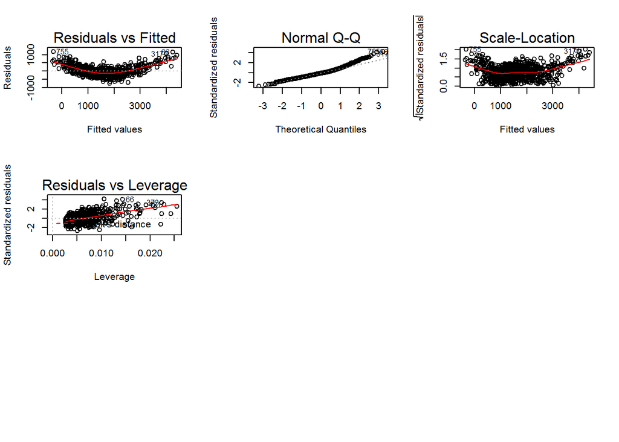

#### based on the multi colinearity check we can remove a independent variable from this model.

### since there exists 99% corealataion between **speed_air** and **speed_ground** and having both these dependent variables may create multicolinearity

```
##                 duration      no_pasg speed_ground    speed_air
## duration      1.00000000 -0.036389581 -0.048970252 -0.037432882
## no_pasg      -0.03638958  1.000000000 -0.001489012 -0.008984225
## speed_ground -0.04897025 -0.001489012  1.000000000  0.995483035
## speed_air    -0.03743288 -0.008984225  0.995483035  1.000000000
## height        0.01111923  0.037308828 -0.051671805 -0.039975462
## pitch        -0.04675348 -0.014447586 -0.051670337 -0.042529606
## distance     -0.05138252 -0.016853121  0.867711454  0.893915962
## make          0.04442907  0.027481474  0.047671438  0.018888186
##                   height       pitch    distance        make
## duration      0.01111923 -0.04675348 -0.05138252  0.04442907
## no_pasg       0.03730883 -0.01444759 -0.01685312  0.02748147
## speed_ground -0.05167181 -0.05167034  0.86771145  0.04767144
## speed_air    -0.03997546 -0.04252961  0.89391596  0.01888819
## height        1.00000000  0.03473959  0.10372080  0.01504748
## pitch         0.03473959  1.00000000  0.06868102 -0.36201268
## distance      0.10372080  0.06868102  1.00000000 -0.22998335
## make          0.01504748 -0.36201268 -0.22998335  1.00000000
```

```
##    speed_air speed_ground       height         make
##    124.19321    124.57264      1.02087      1.10591
```

### decision or conclusion:

#### we can infer from the result that there exists a multi colinearity between speed_air and speed_ground as their corelation value is 0.99

#### we can infer from the VIF values of speed_air and speed_ground have high values which infer there is a multi colinearity between speed_air and speed_ground

#### the **speed_air** has high coreleation with distance compared with **speed_ground**.Therefore we remove **speed_ground** independent variable from the model and build a new model

### Goal :build a model with 3 independent variables and check how good it fits the data.

```
##
## Call:
## lm(formula = distance ~ (speed_air + height + make), data = landing_DAMdata)
##
## Residuals:
##     Min      1Q  Median      3Q     Max
## -644.50 -197.95  -79.35  111.66 1326.97
##
## Coefficients:
##               Estimate Std. Error t value Pr(>|t|)
## (Intercept) -2627.5988    67.8134  -38.75   <2e-16 ***
## speed_air      48.7320     0.6685   72.89   <2e-16 ***
## height         13.3393     1.1522   11.58   <2e-16 ***
## make         -450.6248    22.4166  -20.10   <2e-16 ***
## ---
## Signif. codes:  0 '***' 0.001 '**' 0.01 '*' 0.05 '.' 0.1 ' ' 1
##
## Residual standard error: 313.1 on 777 degrees of freedom
## Multiple R-squared:  0.8806, Adjusted R-squared:  0.8802
## F-statistic:  1911 on 3 and 777 DF,  p-value: < 2.2e-16
```

```
## Analysis of Variance Table
##
## Response: distance
##            Df    Sum Sq   Mean Sq F value    Pr(>F)
## speed_air   1 510025475 510025475  5201.9 < 2.2e-16 ***
## height      1  12432669  12432669   126.8 < 2.2e-16 ***
## make        1  39620750  39620750   404.1 < 2.2e-16 ***
## Residuals 777  76182366     98047
## ---
## Signif. codes:  0 '***' 0.001 '**' 0.01 '*' 0.05 '.' 0.1 ' ' 1
```

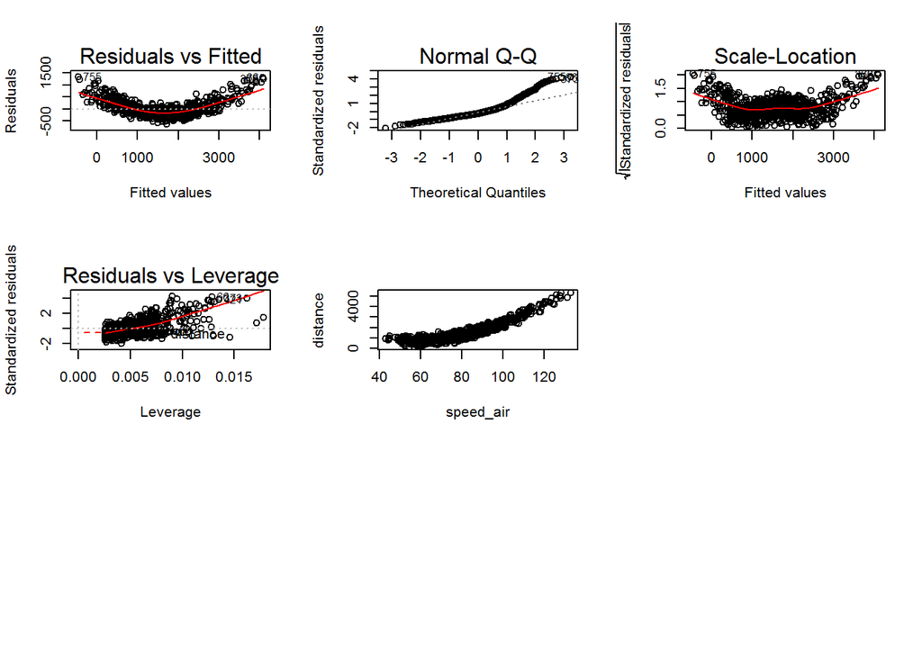

### Observation:we can observe that there is a curve between distance and speed_air

### decision: to remove the curve i have done the polynomial regression to remove and curve and to get a linear regression.

#### Doing polynomial regression to the power of 2 for speed_air independent variable following is the plot

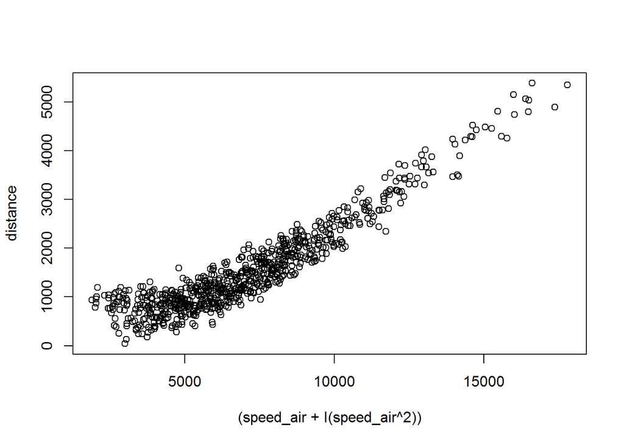

#### we can still reduce the curve by taking polynomial regression to the power 3 for **speed_air**

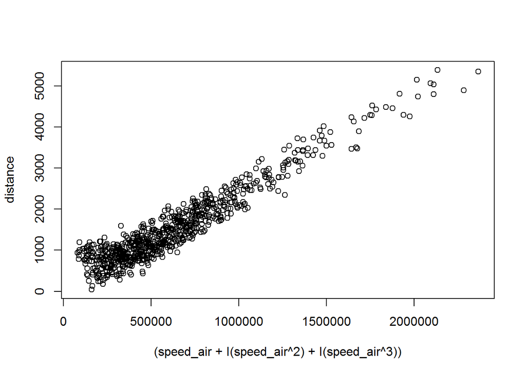

####from the above plot we can say that there is no curve in the plot.

#### Goal :now lets create two multiple regression models for with polynomail regression of order 2 and 3 for **speed_air**

### model where **speed_air** is raised to the power of two using polynomial regression

```
##
## Call:
## lm(formula = distance ~ (speed_air + I(speed_air^2) + height +
##     make))
##
## Residuals:
##     Min      1Q  Median      3Q     Max
## -390.86  -83.05    2.00   83.68  438.70
##
## Coefficients:
##                  Estimate Std. Error t value Pr(>|t|)
## (Intercept)    2547.97973   85.01289   29.97   <2e-16 ***
## speed_air       -79.96862    2.02209  -39.55   <2e-16 ***
## I(speed_air^2)    0.76332    0.01189   64.21   <2e-16 ***
## height           13.10677    0.45891   28.56   <2e-16 ***
## make           -377.08761    9.00111  -41.89   <2e-16 ***
## ---
## Signif. codes:  0 '***' 0.001 '**' 0.01 '*' 0.05 '.' 0.1 ' ' 1
##
## Residual standard error: 124.7 on 776 degrees of freedom
## Multiple R-squared:  0.9811, Adjusted R-squared:  0.981
## F-statistic: 1.007e+04 on 4 and 776 DF,  p-value: < 2.2e-16
```

```
## Analysis of Variance Table
##
## Response: distance
##                 Df    Sum Sq   Mean Sq  F value    Pr(>F)
## speed_air        1 510025475 510025475 32794.11 < 2.2e-16 ***
## I(speed_air^2)   1  76795665  76795665  4937.88 < 2.2e-16 ***
## height           1  12076191  12076191   776.49 < 2.2e-16 ***
## make             1  27295304  27295304  1755.06 < 2.2e-16 ***
## Residuals      776  12068624     15552
## ---
## Signif. codes:  0 '***' 0.001 '**' 0.01 '*' 0.05 '.' 0.1 ' ' 1
```

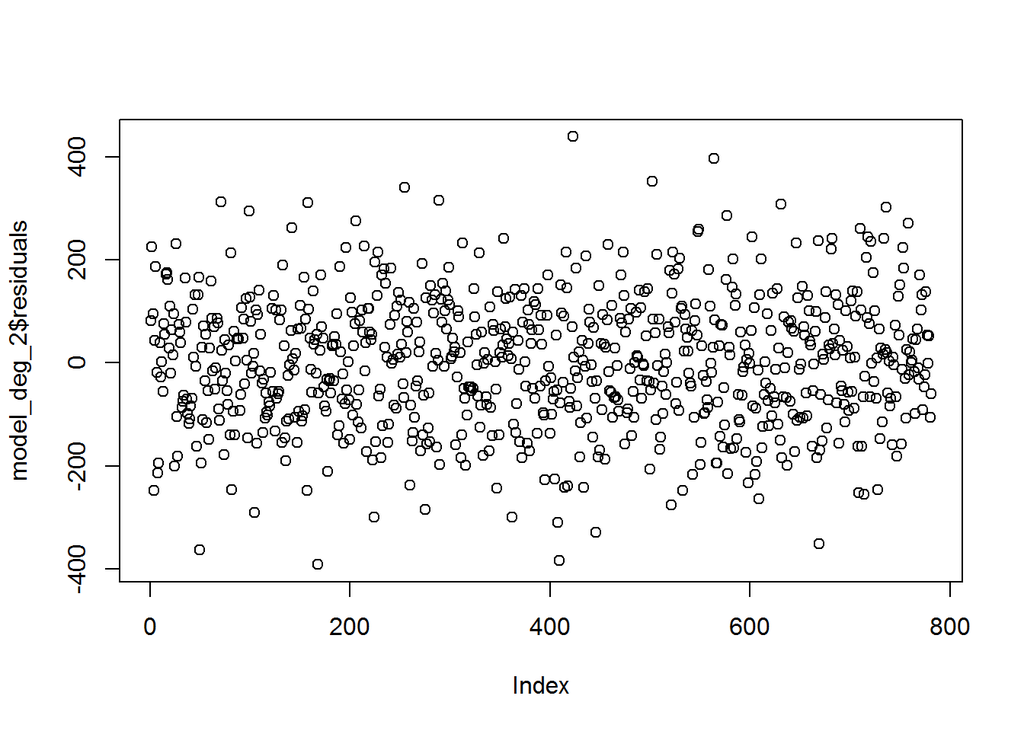

#### model where **speed_air** is raised to the power of three using polynomial regression

```
##
## Call:
## lm(formula = distance ~ (speed_air + I(speed_air^2) + I(speed_air^3) +
##     height + make))
##
## Residuals:
##     Min      1Q  Median      3Q     Max
## -389.94  -84.75    0.87   81.74  437.37
##
## Coefficients:
##                  Estimate Std. Error t value Pr(>|t|)
## (Intercept)     4.113e+03  2.949e+02  13.946  < 2e-16 ***
## speed_air      -1.387e+02  1.080e+01 -12.843  < 2e-16 ***
## I(speed_air^2)  1.472e+00  1.286e-01  11.448  < 2e-16 ***
## I(speed_air^3) -2.744e-03  4.960e-04  -5.533 4.31e-08 ***
## height          1.297e+01  4.511e-01  28.753  < 2e-16 ***
## make           -3.764e+02  8.835e+00 -42.605  < 2e-16 ***
## ---
## Signif. codes:  0 '***' 0.001 '**' 0.01 '*' 0.05 '.' 0.1 ' ' 1
##
## Residual standard error: 122.4 on 775 degrees of freedom
## Multiple R-squared:  0.9818, Adjusted R-squared:  0.9817
## F-statistic:  8366 on 5 and 775 DF,  p-value: < 2.2e-16
```

```
## Analysis of Variance Table
##
## Response: distance
##                 Df    Sum Sq   Mean Sq   F value    Pr(>F)
## speed_air        1 510025475 510025475 34045.578 < 2.2e-16 ***
## I(speed_air^2)   1  76795665  76795665  5126.318 < 2.2e-16 ***
## I(speed_air^3)   1    880661    880661    58.786 5.268e-14 ***
## height           1  11757178  11757178   784.823 < 2.2e-16 ***
## make             1  27192263  27192263  1815.157 < 2.2e-16 ***
## Residuals      775  11610017     14981
## ---
## Signif. codes:  0 '***' 0.001 '**' 0.01 '*' 0.05 '.' 0.1 ' ' 1
```

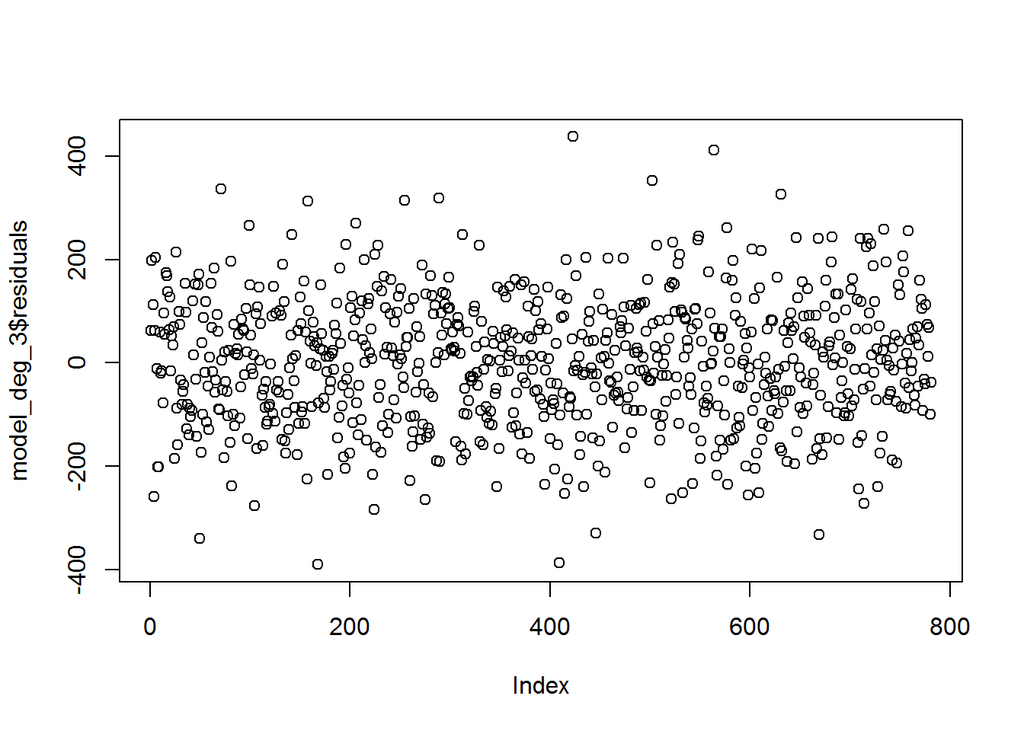

### Model Adequency:

#### Goal: Here we need to check the residual plots normal distribution , QQ plots and histograms to check whether the model is the best fit

```
##
## Call:
## lm(formula = distance ~ (speed_air + I(speed_air^2) + height +
##     make))
##
## Residuals:
##     Min      1Q  Median      3Q     Max
## -390.86  -83.05    2.00   83.68  438.70
##
## Coefficients:
##                  Estimate Std. Error t value Pr(>|t|)
## (Intercept)    2547.97973   85.01289   29.97   <2e-16 ***
## speed_air       -79.96862    2.02209  -39.55   <2e-16 ***
## I(speed_air^2)    0.76332    0.01189   64.21   <2e-16 ***
## height           13.10677    0.45891   28.56   <2e-16 ***
## make           -377.08761    9.00111  -41.89   <2e-16 ***
## ---
## Signif. codes:  0 '***' 0.001 '**' 0.01 '*' 0.05 '.' 0.1 ' ' 1
##
## Residual standard error: 124.7 on 776 degrees of freedom
## Multiple R-squared:  0.9811, Adjusted R-squared:  0.981
## F-statistic: 1.007e+04 on 4 and 776 DF,  p-value: < 2.2e-16
```

```
## Analysis of Variance Table
##
## Response: distance
##                 Df    Sum Sq   Mean Sq  F value    Pr(>F)
## speed_air        1 510025475 510025475 32794.11 < 2.2e-16 ***
## I(speed_air^2)   1  76795665  76795665  4937.88 < 2.2e-16 ***
## height           1  12076191  12076191   776.49 < 2.2e-16 ***
## make             1  27295304  27295304  1755.06 < 2.2e-16 ***
## Residuals      776  12068624     15552
## ---
## Signif. codes:  0 '***' 0.001 '**' 0.01 '*' 0.05 '.' 0.1 ' ' 1
```

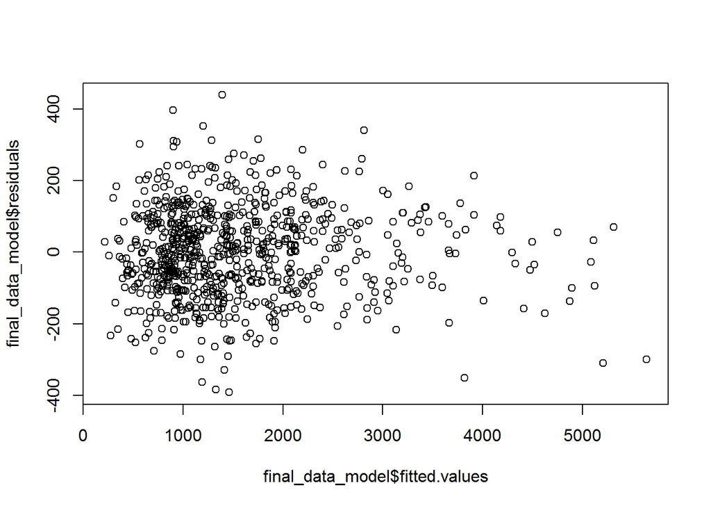

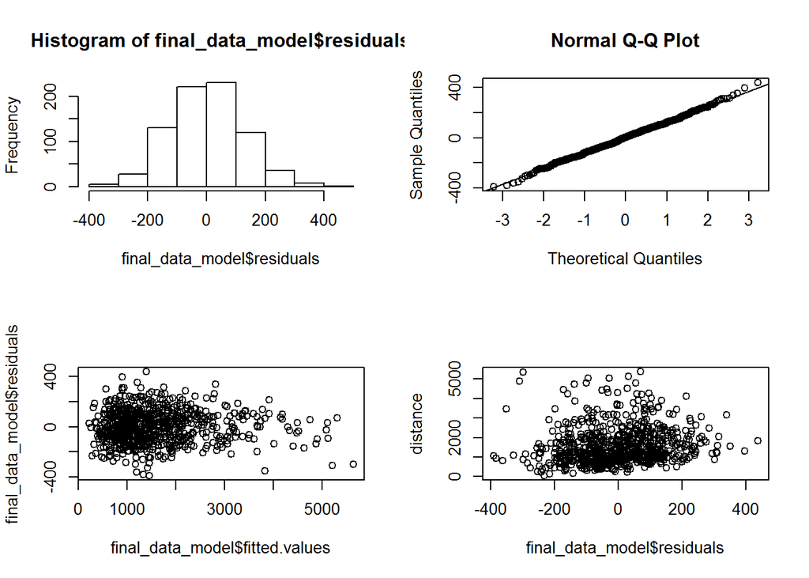

### calculating the F-test

```
## [1] "F value is 10065.8845330498"
```

```
## [1] "P value is 0"
```